BACK TO SCHEDULE

- Introduction
- The Sampling Distribution $\bar{p}$
- The Central Limit Theorem
- Effect of Sample Size

# Introduction

In practice, statistical studies involve sampling several, perhaps many, individuals.

We often compute numerical summaries of samples, and the most commonly used summary are the sample mean and sample proportion.

If several samples are drawn from a population, they are likely to have different values for the sample mean (or proportion).

Because the value of the sample mean (or proportion) varies each time a sample is drawn, the sample mean (or proportion) is a **random variable**, and it has a probability distribution.

The probability distribution of the sample mean is called the *sampling distribution of $\bar{X}$*. Similarly, the sampling distribution of the sample proportion is called the *sampling distribution of $\hat{p}$.*

# The Sampling Distribution of the Sample Proportion, $\hat{p}$

When random samples are selected from a population, the following are properties of the sampling distribution of $\hat{p}$:

> $\mu_{\hat{p}}$ = p. The $\hat{p}$ is the sample proportion, **p** is the population proportion and $\mu_{\hat{p}}$ is the mean of the $\hat{p}$ sampling distribution.

> $\sigma_{\hat{p}}$ = $\sqrt{\frac{p(1 - p)}{n}}$. The sample size is **n** and $\sigma_{\hat{p}}$ is the standard deviation of the $\hat{p}$.

> When **n** is large and **p** is not near 0 or 1, the sampling distribution of $\hat{p}$ is approximately normal.

The farther the value of **p** is from 0.5 the larger **n** must be in order for the sampling distribution of $\hat{p}$ to be approximately normal.

A conservative rule of thumb is that if BOTH **np $\geq$ 10** and **n(1 - p) $\geq$ 10** then a normal distribution provides a reasonable approximation to the sampling distribution of $\hat{p}$

**Exercise:** According to a Harris poll, chocolate is the favorite ice cream flavor for 27% of Americans. If a sample of 100 Americans is taken, what is the probability that the sample proportion of those who prefer chocolate is greater than 0.30?

> Step 1: Compute the mean of $\hat{p}$: $\mu_{\hat{p}}$ = p = 0.27

> Step 2: Compute the standard deviation of $\hat{p}$: $\sigma_{\hat{p}}$ = $\sqrt{\frac{p(1 - p}{n}}$ = $\sqrt{\frac{(0.27)(1 - 0.27)}{100}}$ = 0.0444

**R GUI - simulation**

> Open R GUI: library(Rcmrd)

> DISTRIBUTIONS > DISCRETE DISTRIBUTIONS > BINOMIAL DISTRIBUTION > SAMPLE FROM BINOMIAL DISTRIBUTION

> Enter name or data set: **icecream**

> Binomial trials: 1, Probability of success: 0.27, Number of samples (rows): 1000, Number of observations (columns): 100 > OK

Display summary of the sampled proportions and compared with the results according to the CTL.

> STATISTICS > SUMMARIES > NUMERICAL SUMMARIES

> Select variable: mean > OK

Display histogram of sampled proportions.

> GRAPHS > HISTOGRAM

> Variable: **mean** > OK

Find probability using simulation results.

> DATA > MANAGE VARIABLES IN ACTIVE DATA SET > COMPUTE NEW VARIABLE

> New variable name: **pct30**

> Expression to compute: **mean > 0.3** > OK

> STATISTICS > SUMMARIES > FREQUENCY DISTRIBUTIONS

> Variables: **pct30** > OK

# The Central Limit Theorem

Let $\bar{X}$ denote the sample mean of a random sample of size n from a population having mean $\mu$ and standard deviation $\sigma$.

The distribution of $\bar{X}$ has a mean denoted by $\mu_{\bar{x}}$ and the standard deviation by $\sigma_{\bar{x}}$.

> Mean of $\bar{X}$ : $\mu_{\bar{x}}$ = $\mu$

> Standard deviation of $\bar{X}$: $\sigma_{\bar{x}}$ = $\frac{\sigma}{\sqrt{n}}$

> Distribution of $\bar{X}$: When the population Normal, the distribution of $\bar{X}$ is also NORMAL for ANY sample size n. Otherwise, the distribution is “approximately” NORMAL for a LARGE sample size, n $\geq$ 30.

**Exercise:** According to the records of a soft drink company, the bottles for their one-liter-sized products contain an average (mean) of 1.015 liters of beverage, with a standard deviation of 0.13 liters. As part of routine quality assurance, a sample of 50 bottles has been taken. The sample mean amount of beverage in these 50 bottles was 0.993 liters.

Assuming the company’s records are correct, find the probability of observing a sample mean of 0.993 liters or less in a sample of 50 bottles. Round your answer to at least three decimal places.

> Compute the Mean of $\bar{X}$: $\mu_{\bar{x}}$ = $\mu$ = 1.015

> Compute the standard deviation of $\bar{X}$: - $\sigma_{\bar{x}}$ = $\frac{\sigma}{\sqrt{n}}$ = $\frac{0.13}{\sqrt{50}}$ = 0.0184

> Find the Z score of the observed sample mean: Z = $\frac{\bar{X} - \mu_{\bar{x}}}{\sigma_{\bar{x}}} = \frac{0.993 - 1.015}{0.0184}$ = -1.196

> Compute the probability using the Z table: P(Z < -1.196) = 0.1158. In ALEKS, use the function P(Z < $_$)

**R GUI - simulation**

> Open R GUI: library(Rcmrd)

> DISTRIBUTIONS > CONTINUOUS DISTRIBUTIONS > NORMAL DISTRIBUTION > SAMPLE FROM NORMAL DISTRIBUTION

> Enter name or data set: **bottles**

> Mean: 1.015, Standard deviation: 0.13, Number of samples (rows): 1000, Number of observations (columns): 50 > OK

Display summary of the sampled proportions and compared with the results according to the CTL.

> STATISTICS > SUMMARIES > NUMERICAL SUMMARIES

> Select variable: mean > OK

Display histogram of sampled proportions.

> GRAPHS > HISTOGRAM

> Variable: **mean** > OK

Find probability using simulation results.

> DATA > MANAGE VARIABLES IN ACTIVE DATA SET > COMPUTE NEW VARIABLE

> New variable name: **less0993**

> Expression to compute: **mean < 0.993** > OK

> STATISTICS > SUMMARIES > FREQUENCY DISTRIBUTIONS

> Variables: **less0993** > OK

# Effect of Sample Size on Sampling Distributions

### Sampling Distribution of $\hat{p}$ (when p = 0.01)

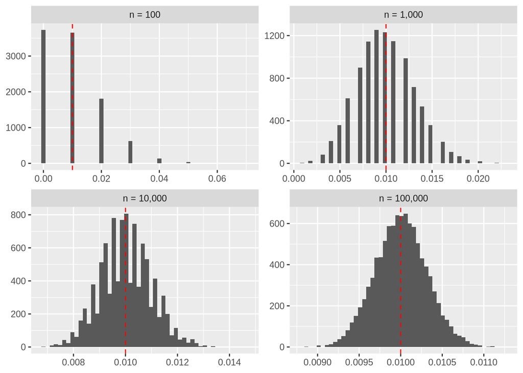

### Sampling Distribution of $\bar{X}$ (when $\mu$ = 5)

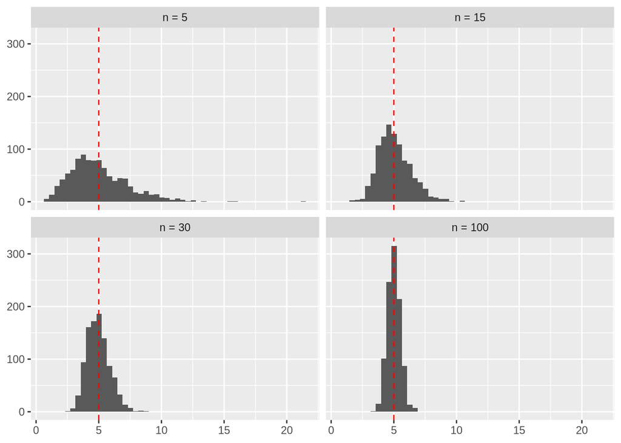